# Datacube processing II

Advanced Geospatial Data Processing for Social Scientists

Dennis Abel & Stefan Jünger

2025-04-29

## Now

| Day | Time | Title |
| --- | --- | --- |
| April 28 | 10:00-11:15 | Introduction |
| April 28 | 11:15-11:30 | Coffee Break |
| April 28 | 11:30-13:00 | Raster data in R |
| April 28 | 13:00-14:00 | Lunch Break |
| April 28 | 14:00-15:15 | Raster data processing |
| April 28 | 15:15-15:30 | Coffee Break |
| April 28 | 15:30-17:00 | Graphical display of raster data in maps |
| April 29 | 10:00-11:15 | Datacube processing I |
| April 29 | 11:15-11:30 | Coffee Break |
| April 29 | 11:30-13:00 | Datacube processing II & API access |
| April 29 | 13:00-14:00 | Lunch Break |
| April 29 | 14:00-15:15 | Data integration and linking (with survey data) |
| April 29 | 15:15-15:30 | Coffee Break |
| April 29 | 15:30-17:00 | Outlook and open session with own application |

## Datacubes - continued

Building on the introduction to data stacks and cubes in `R`, we now want to dig deeper into wrangling with these objects. We will:

- cover more advanced raster operations,
- have a case study on accessing remote sensing data from an API,
- and we will briefly revise visualizing with `ggplot` - this time with our raster stacks/cubes.

## Visualizing datacubes

Yesterday, you learned about visualizing `SpatRaster` objects with `ggplot`. Extending this approach to raster stacks and cubes is quite straightforward. We can create multiple graphs within one plot (“facets”) with `ggplot` which allows us to visualize two or more layers in one plot.

Many of you will know `facet_wrap()` or `facet_grid()` to separate standard graphs like scatterplots by a third grouping variable. The same logic applies to our third layer dimension (which in our case represents time but could potentially be any other band like RGB).

## Visualizing `terra` raster stacks

We will start with our `terra` `SpatRaster` and load the raster stack created in the previous session.

```r
CA_pop_stack <- terra::rast("./data/CA_pop_stack.tif")

CA_pop_stack
```

```
class       : SpatRaster
dimensions  : 1287, 1168, 4  (nrow, ncol, nlyr)
resolution  : 828.2603, 828.2603  (x, y)
extent      : -415531, 551877.1, -607609.6, 458361.4  (xmin, xmax, ymin, ymax)
coord. ref. : NAD83 / California Albers (EPSG:3310)
source      : CA_pop_stack.tif
names       : pop_2017, pop_2018, pop_2019, pop_2020
min values  :      0.0,     0.00,     0.00,     0.00
max values  :  22052.6, 22123.96, 22208.66, 22285.26
unit        :    count,    count,    count,    count
time (years): 2017 to 2020
```

## Visualizing `terra` raster stacks

You know the drill - `ggplot()` initializes our blank canvas which we fill with our geoms. `tidyterra's` `geom_spatraster()` is used for plotting `SpatRaster` objects. With your knowledge on indexing single layers within a raster stack, we can create a single plot like yesterday.

```r
library(tidyterra)
library(scales)

ggplot()+
  geom_spatraster(data = CA_pop_stack[[1]])+
  scale_fill_viridis_c(na.value = "transparent",
                       name = "Pop count",
                       limits = c(0, 2000),
                       oob = scales::squish)+
  theme_minimal()
```

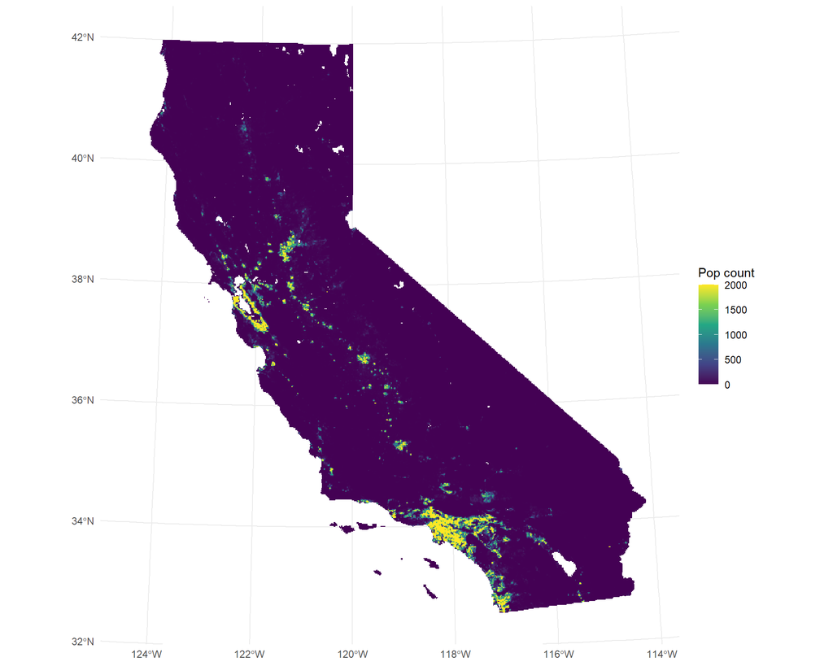

## Visualizing `terra` raster stacks

Single layers can also be accessed with the layer name supplied to the `aes(fill=)` argument in `geom_spatraster()`.

```r
library(tidyterra)
library(scales)

ggplot()+
  geom_spatraster(data = CA_pop_stack,
                  aes(fill = pop_2017)
                  )+
  scale_fill_viridis_c(na.value = "transparent",
                       name = "Pop count",
                       limits = c(0, 2000),
                       oob = scales::squish)+
  theme_minimal()
```

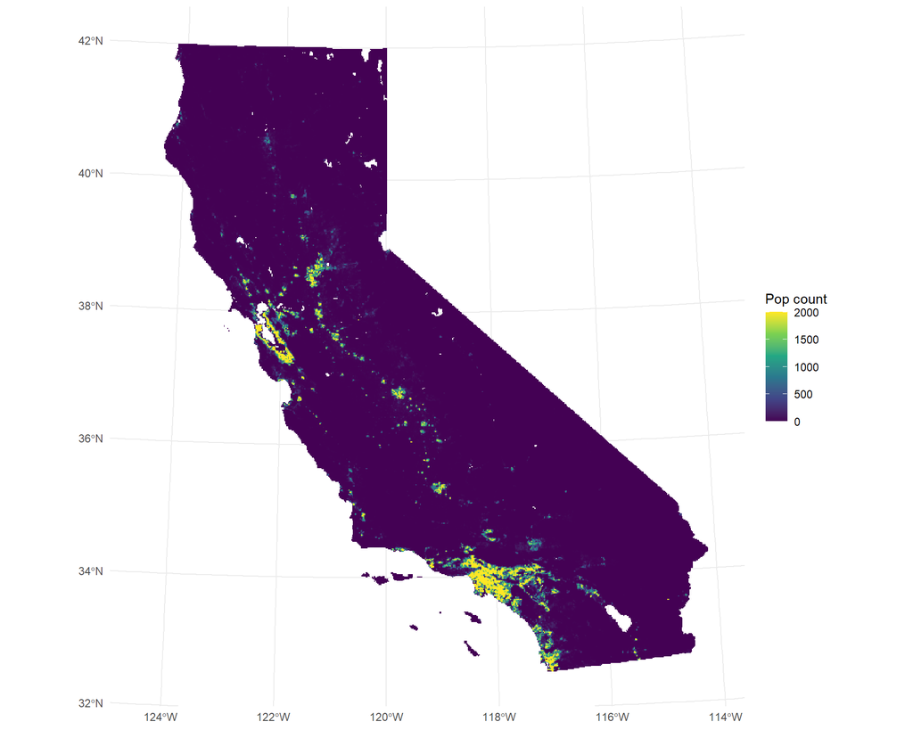

## Visualizing `terra` raster stacks

For visualizing all four layers simultaneously, we can utilize the `facet_wrap()` command. Instead of providing the name of a third variable to the command, we call `lyr`, which `geom_spatraster()` recognizes as the third dimension.

```r
ggplot()+
  geom_spatraster(data = CA_pop_stack)+
  scale_fill_viridis_c(na.value = "transparent",
                       name = "Pop count",
                       limits = c(0, 2000),
                       oob = scales::squish)+
  facet_wrap(~ lyr)+
  theme_minimal()
```

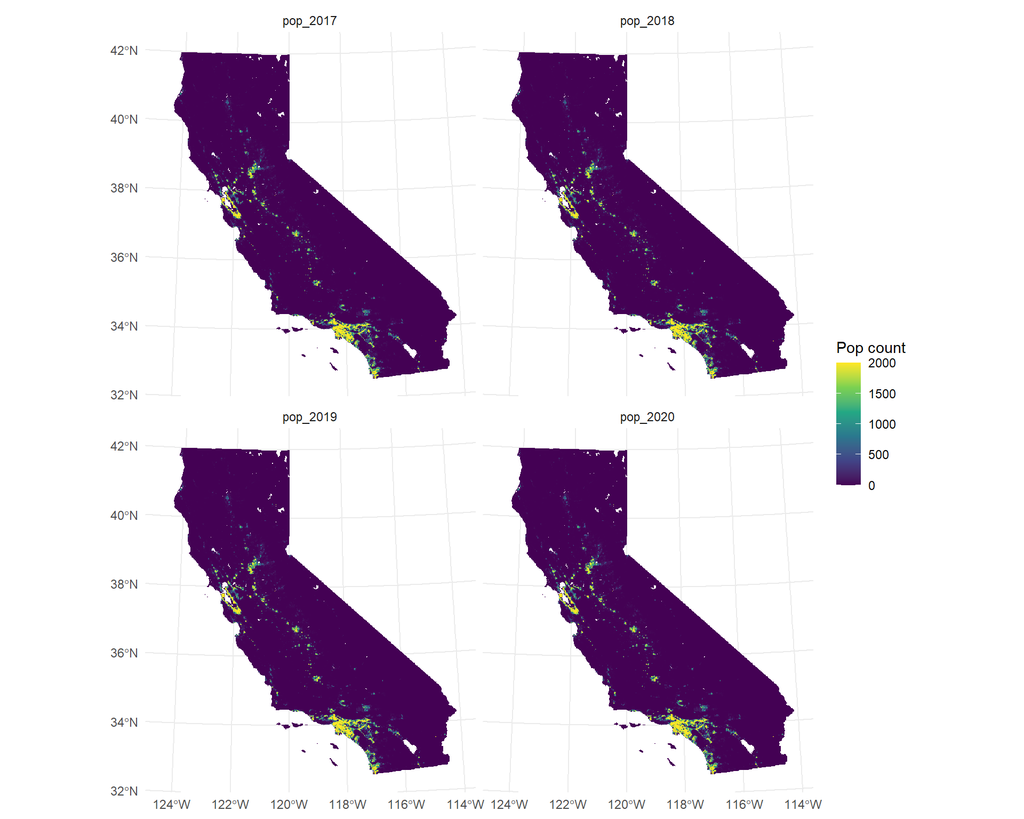

## Visualizing `terra` raster stacks

Creating custom labels for your facets can generally be quite painful (not just for geodata). By default, it uses the values from the `names` of the `SpatRaster` attribute. If you want to change labels, you either change the `names` values (which we often don’t want to) or create a workaround. For example, here we would like to use the `time` values.

```r
facet_labels <- function(label) {
  years <- as.character(terra::time(CA_pop_stack))
  names(years) <- names(CA_pop_stack)
  new_label <- unname(years[label])
  new_label
}

ggplot()+
  geom_spatraster(data = CA_pop_stack)+
  scale_fill_viridis_c(na.value = "transparent",
                       name = "Pop count",
                       limits = c(0, 2000),
                       oob = scales::squish)+
  facet_wrap(~ lyr,
             labeller = labeller(
               lyr = facet_labels
             )
  )+
  theme_minimal()
```

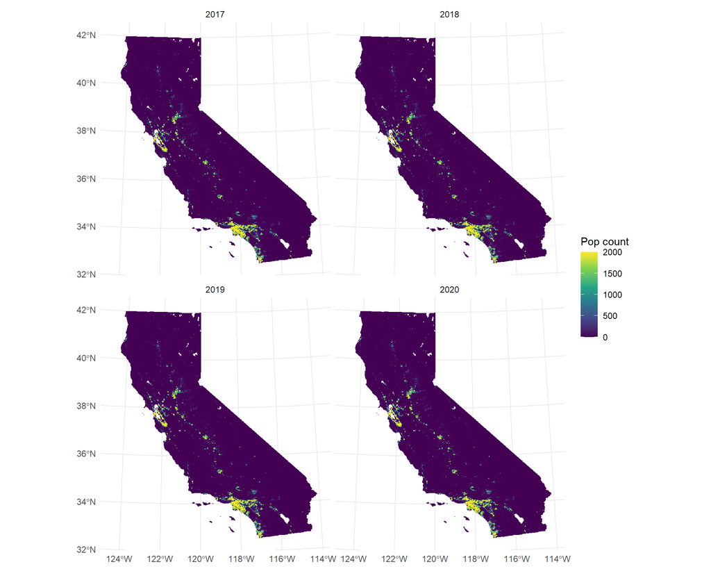

## Visualizing `terra` raster stacks

Polishing your graph is business-as-usual.

```r
library(ggspatial)

facet_labels <- function(label) {
  years <- as.character(terra::time(CA_pop_stack))
  names(years) <- names(CA_pop_stack)
  new_label <- unname(years[label])
  new_label
}

ggplot()+
  geom_spatraster(data = CA_pop_stack)+
  scale_fill_viridis_c(na.value = "transparent",
                       name = "Pop count",
                       limits = c(0, 2000),
                       oob = scales::squish)+
  facet_wrap(~ lyr,
             labeller = labeller(
               lyr = facet_labels
             )
  )+
  theme_minimal()+
  labs(
    title = "Population in California",
    subtitle = "In absolute numbers on 1x1km grid",
    caption = "Source: WorldPop (2018)"
  ) +
  annotation_scale(
    location = "bl",
    width_hint = 0.3
  ) +
  annotation_north_arrow(
    location = "tr",
    which_north = "true",
    style = north_arrow_fancy_orienteering
  )
```

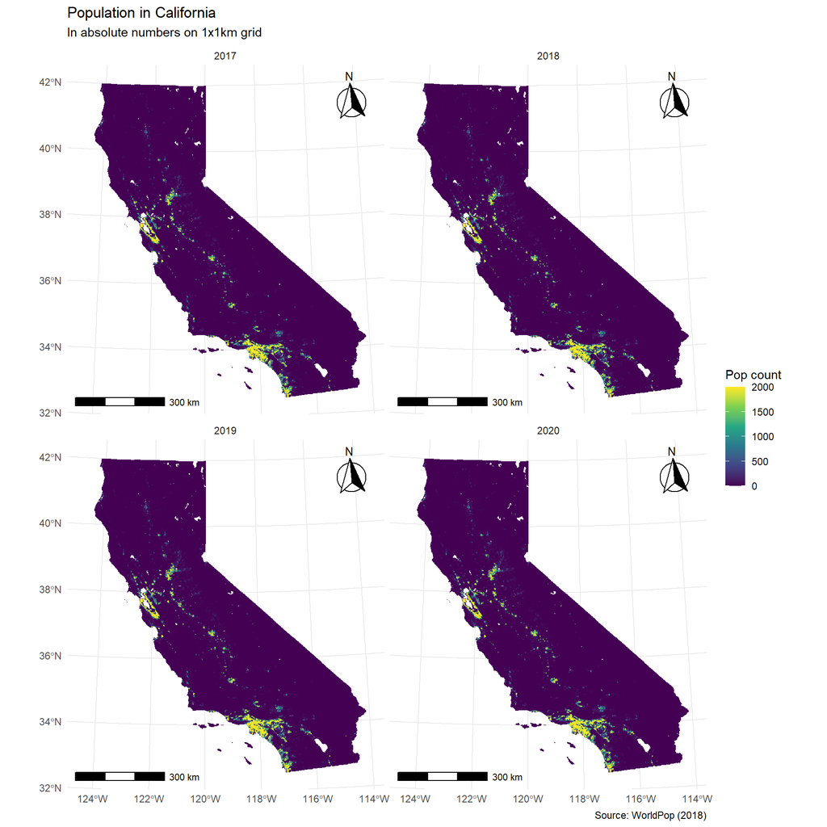

## Visualizing `stars` raster cubes

Now we turn towards our `stars` datacubes and explore the visualization options. First, we load the raster cube created in the previous session.

```r
CA_pop_cube <- readRDS("./data/CA_pop_cube.rds")

CA_pop_cube
```

```
stars object with 3 dimensions and 1 attribute
attribute(s), summary of first 1e+05 cells:
                   Min. 1st Qu. Median     Mean   3rd Qu.     Max.  NA's
population [count]    0       0      0 2.112075 0.1045545 1906.748 71165
dimension(s):
     from   to  offset delta                    refsys x/y
x       1 1234 -415531 783.7 NAD83 / California Albers [x]
y       1 1136  458361  -930 NAD83 / California Albers [y]
time    1    4    2017     1                        NA
```

## Visualizing `stars` raster cubes

Base `R` plotting of `stars` objects is possible. However, the default color-scheme is limited and often results in plots like this one which are relatively uninformative. It would require manual workarounds on breaks to adjust this. We prefer to directly move on to `ggplot`.

```r
plot(CA_pop_cube[,,,1])
```

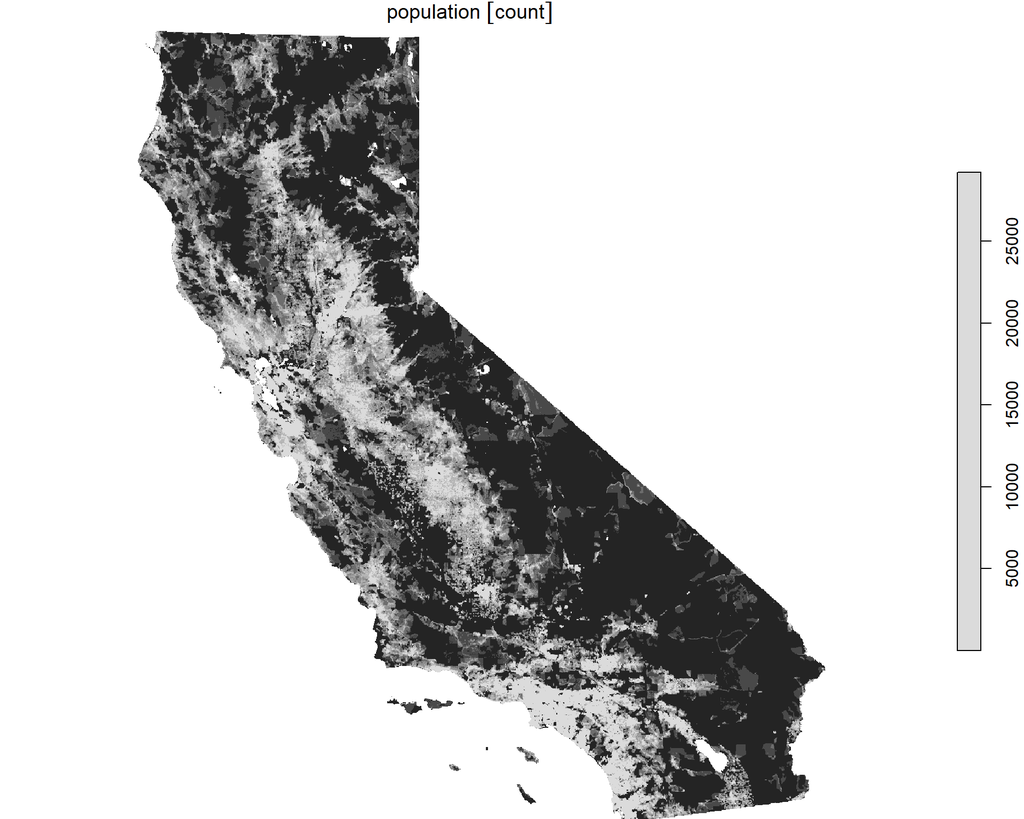

## Visualizing `stars` raster cubes

Setting up your visualization with `ggplot` is very similar to the approach before for `SpatRaster` data. `geom_stars` allows us to directly input a stars object.

```r
ggplot() +
  geom_stars(data = CA_pop_cube[,,,1],
             aes(fill = population)
             ) +
  scale_fill_viridis_c(na.value = "transparent",
                       name = "Pop count",
                       limits = c(0, 2000),
                       oob = scales::squish)+
  coord_equal() +
  theme_minimal()
```

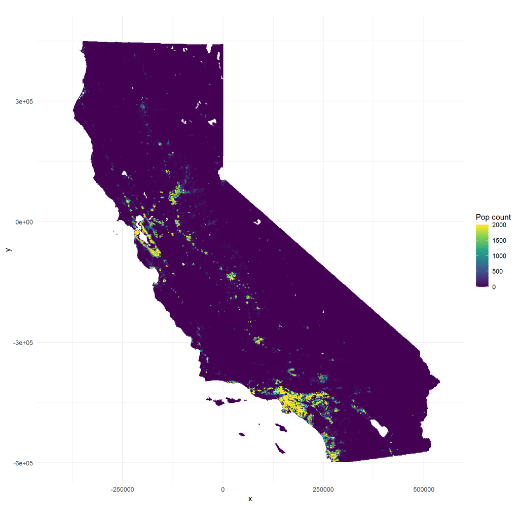

## Visualizing `stars` raster cubes

With `facet_wrap`, we can create a combination of several layers into one plot. Given that `stars` objects can have *>1* bands, we specify it with the exact name. Here it is “time”. Facet labels are directly derived from that band. We do not need to wrangle with labeling further.

```r
ggplot() +
  geom_stars(data = CA_pop_cube,
             aes(fill = population)
             ) +
  scale_fill_viridis_c(na.value = "transparent",
                       name = "Pop count",
                       limits = c(0, 2000),
                       oob = scales::squish)+
  coord_equal() +
  facet_wrap(~ time)+
  theme_minimal()+
  labs(
    title = "Population in California",
    subtitle = "In absolute numbers on 1x1km grid",
    caption = "Source: WorldPop (2018)"
  ) +
  annotation_scale(
    location = "bl",
    width_hint = 0.3
  ) +
  annotation_north_arrow(
    location = "tr",
    which_north = "true",
    style = north_arrow_fancy_orienteering
  )
```

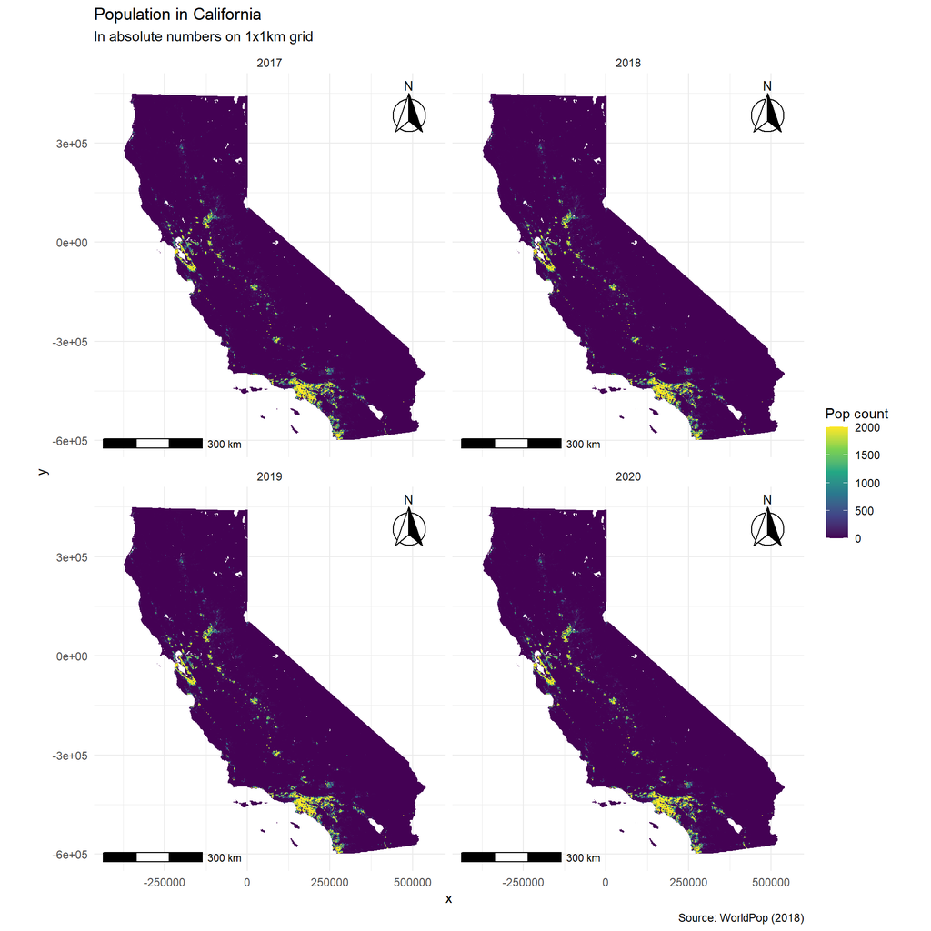

## Case study - Nighttime lights

Now that we have established an understanding of raster stacks and cubes in `R`, we would like to introduce a case study in nighttime lights. We will briefly introduce:

- Remote sensing and how nighttime lights data is generated,
- how we can access that data via a public API and,
- how to wrangle with that data.

In particular, we will focus on working with and “harmonizing” raster layers with different spatial properties.

## APIs

Geospatial data tend to be quite big, and there’s a pressure to distribute data efficiently. Data dumps (on the internet) may not be helpful

- When resources are low
- Time’s a factor
- The data have a large geographic extent

Instead, a *Programming Application Interface* (API) is often used.

## Data providers offering geospatial data APIs

- [OpenStreetMap](https://wiki.openstreetmap.org/wiki/API)
- [Google](https://developers.google.com/maps/documentation/geolocation/overview)
- [Bing](https://docs.microsoft.com/en-us/bingmaps/rest-services/locations/)
- [Copernicus Climate Data Store](https://cds.climate.copernicus.eu/)
- …
- [Cologne’s Open Data Portal](https://www.offenedaten-koeln.de/dataset/taxonomy/term/44/field_tags/Geo-44)
- Specialized `R` packages, such as the [`wiesbaden` package](https://cran.r-project.org/web/packages/wiesbaden/index.html) or the [`tidycensus` package](https://cran.r-project.org/web/packages/tidycensus/index.html)

## R package `blackmarbler`

`blackmarbleR` by Robert Marty and Gabriel Stefanini Vicente (2025) supports easy access to NASA’s Black Marble API. Let’s check out their [vignette](https://worldbank.github.io/blackmarbler/) to set up an account and the data retrieval.

```r
library(blackmarbler)
```

[figure not shown]

## NASA’s Black Marble

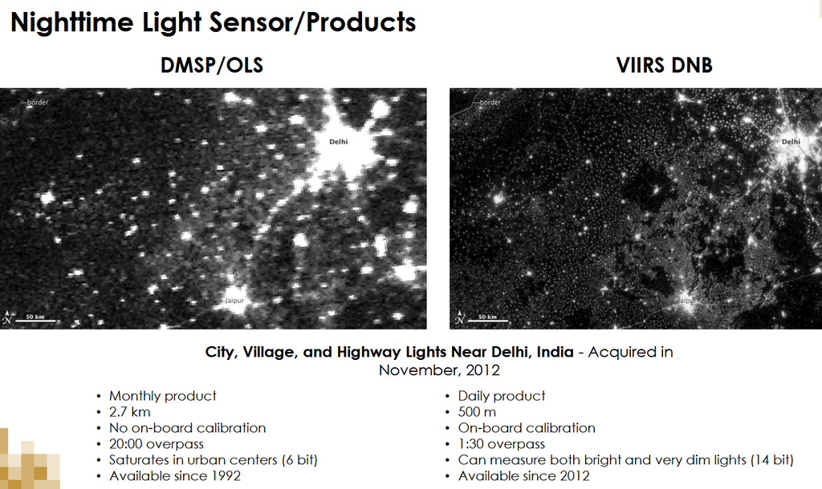

[Source](https://appliedsciences.nasa.gov/sites/default/files/2020-12/BlackMarble_2020.pdf)

## NASA’s Black Marble

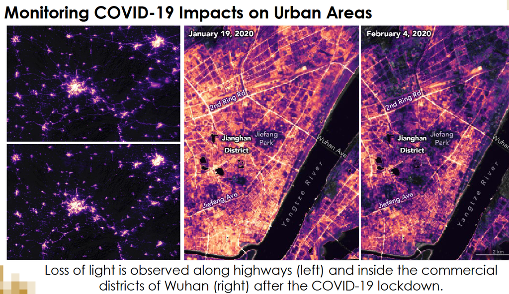

[Source](https://appliedsciences.nasa.gov/sites/default/files/2020-12/BlackMarble_2020.pdf)

## Data retrieval

The function `bm_raster()` to retrieve the nighttime lights requires as input an `sf`object to determine the spatial extent of the downloaded data. The object must be in **WGS84**.

We will focus on California. Let’s load US states shapefiles with the `tigris` package and subset to California.

```r
CA_sf <- tigris::states(progress_bar=FALSE) |>
  dplyr::filter(STUSPS == "CA") |>
  sf::st_transform(crs = "EPSG:4326")

print(CA_sf)

plot(sf::st_geometry(CA_sf))
```

```
Simple feature collection with 1 feature and 15 fields
Geometry type: MULTIPOLYGON
Dimension:     XY
Bounding box:  xmin: -124.482 ymin: 32.52951 xmax: -114.1312 ymax: 42.0095
Geodetic CRS:  WGS 84
  REGION DIVISION STATEFP  STATENS GEOID     GEOIDFQ STUSPS       NAME LSAD
1      4        9      06 01779778    06 0400000US06     CA California   00
  MTFCC FUNCSTAT        ALAND      AWATER    INTPTLAT     INTPTLON
1 G4000        A 403673433805 20291632828 +37.1551773 -119.5434183
                        geometry
1 MULTIPOLYGON (((-119.9999 4...
```

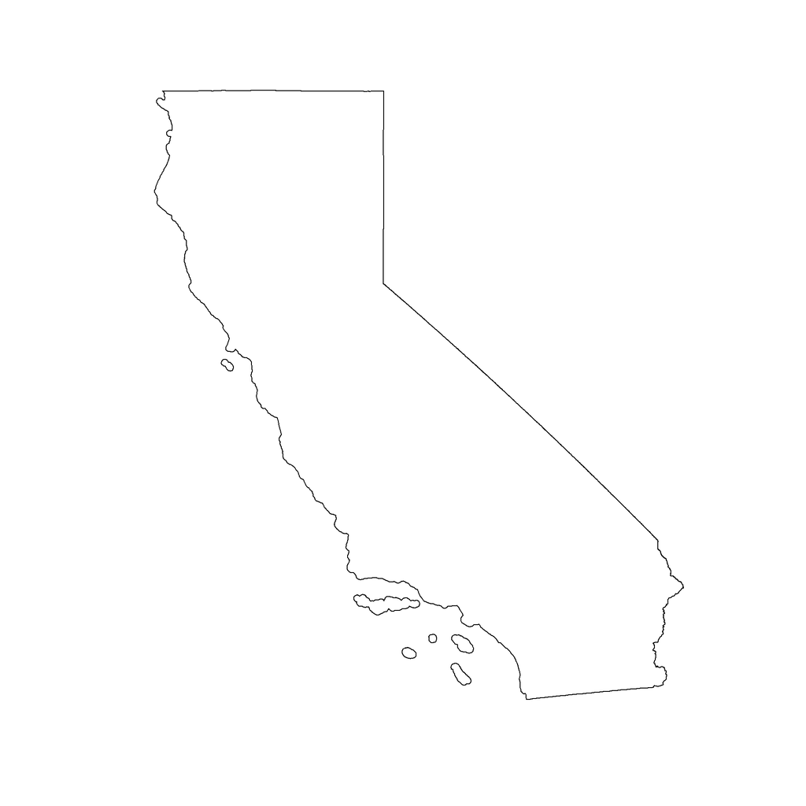

## Data retrieval

Once you have set up your profile at [NASA’s Earth Data Portal](https://urs.earthdata.nasa.gov/) and generated your API token, you can assign it to an object in `R` for the data retrieval.

*NOTE*: I stored mine as an environment variable in the system so that I don’t hard code it into these slides. If you work locally on your own laptop, this is not necessary.

```r
bearer <- Sys.getenv("NASA-token")

# If you work locally, directly assign it
# bearer <- "YOUR_TOKEN"
```

## Data retrieval

We are ready to download the data from NASA’s API.

```r
CA_nl_stack <- bm_raster(roi_sf = CA_sf,
                         product_id = "VNP46A4", # for yearly data
                         date = 2017:2020, # same four years like our population data
                         bearer = bearer, # your API token
                         output_location_type = "file", # we want to store geotiff on disk
                         file_dir = "./data/", # where to store geotiff
                         file_return_null = FALSE # also create SpatRaster file
)
```

## Data retrieval

By default, the function writes the data to the `R` environment (`output_location_type = "memory"`). If you want to store it as single GeoTIFFs, specify `output_location_type = "file` and the file path with `file_dir=`. `file_return_null=` further specifies whether the data is additionally loaded to the `R` environment.

In the previous step, we wrote the data to the disk. Let’s load a single layer for 2020 to inspect the data a bit further.

```r
CA_nl_2020 <- terra::rast("./data/VNP46A4_NearNadir_Composite_Snow_Free_qflag_t2020.tif")

print(CA_nl_2020)
```

```
class       : SpatRaster
dimensions  : 2275, 2485, 1  (nrow, ncol, nlyr)
resolution  : 0.004166667, 0.004166667  (x, y)
extent      : -124.4833, -114.1292, 32.52917, 42.00833  (xmin, xmax, ymin, ymax)
coord. ref. : lon/lat WGS 84 (EPSG:4326)
source      : VNP46A4_NearNadir_Composite_Snow_Free_qflag_t2020.tif
name        : t2020
min value   :   0.0
max value   : 269.2
```

## Data retrieval

The data is right-skewed. We perform a log-transformation to account for that.

Let’s inspect the data visually.

```r
CA_nl_2020[] <- log(CA_nl_2020[] + 1)

ggplot() +
  geom_spatraster(data = CA_nl_2020) +
  geom_sf(data = CA_sf,
          fill = "transparent",
          color = "white",
          size = 4) +
  scale_fill_gradient2(low = "black",
                       mid = "yellow",
                       high = "red",
                       midpoint = 3,
                       na.value = "transparent") +
  labs(title = "Nighttime Lights in California 2020") +
  coord_sf() +
  theme_void() +
  theme(plot.title = element_text(face = "bold", hjust = 0.5),
        legend.position = "none")
```

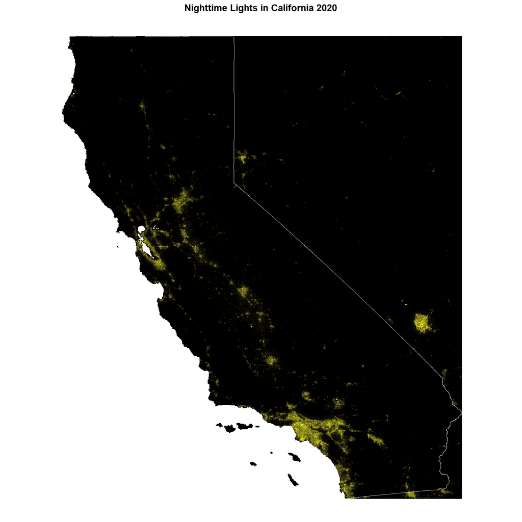

## Layers with different properties

We want to utilize this NL data to explore a bit further how to create and process raster stacks. This time, we will focus on situations with more than one variable and on cases where the spatial properties of the different layers do not match. We will work with night lights and population data in 2020.

We will zoom to Los Angeles County for this exercise.

```r
# Load LA County file
LA_county <- tigris::counties("CA",
                              progress_bar = FALSE
                              ) |>
  filter(NAME == "Los Angeles") |>
  st_transform(crs = "EPSG:4326")

# Subset to "mainland" California and
# exclude the two islands Santa Catalina and San Clemente
LA_county <- LA_county %>%
  st_cast("POLYGON") %>%
  mutate(area = st_area(.)) %>%
  slice_max(area, n = 1)
```

[output not shown]

[figure not shown]

## Layers with different properties

Having our spatial `sf` file properly set up, we can now prep our two raster files.

```r
# Create LA raster files for population and night lights in 2020
LA_pop_2020 <- terra::rast("./data/US-CA_ppp_2020_1km.tif") |>
  terra::mask(terra::vect(LA_county)) |>
  terra::crop(LA_county)

LA_pop_2020[] <- log(LA_pop_2020[] + 1)

LA_nl_2020 <- terra::mask(CA_nl_2020,
                          terra::vect(LA_county)) |>
  terra::crop(LA_county)
```

## Layers with different properties

Visually, there is a strong positive relationship between nighttime lights and population in LA.

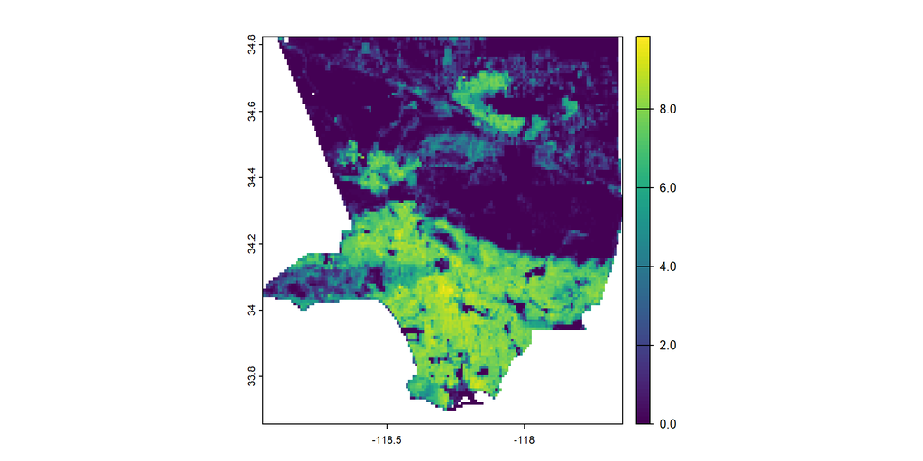

```r
plot(LA_pop_2020)
```

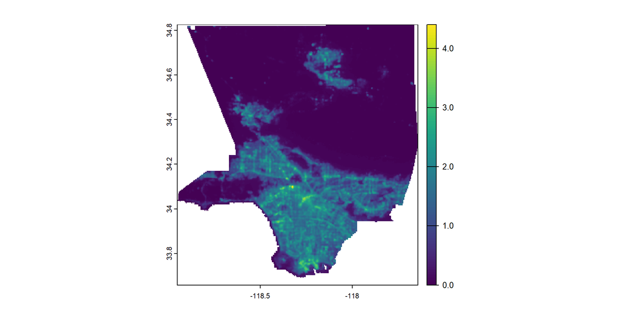

```r
plot(LA_nl_2020)
```

## Layers with different properties

Our two raster files have the same CRS and (almost same) spatial extent. Unfortunately, the resolution (cell size) differs. Our population data is on an approx. 1km grid and our night lights data on an approx. 500m grid.

```r
print(LA_pop_2020)
```

```
class       : SpatRaster
dimensions  : 140, 157, 1  (nrow, ncol, nlyr)
resolution  : 0.008333333, 0.008333333  (x, y)
extent      : -118.9512, -117.6429, 33.65792, 34.82458  (xmin, xmax, ymin, ymax)
coord. ref. : lon/lat WGS 84 (EPSG:4326)
source(s)   : memory
varname     : US-CA_ppp_2020_1km
name        : US-CA_ppp_2020_1km
min value   :           0.000000
max value   :           9.843707
```

```r
print(LA_nl_2020)
```

```
class       : SpatRaster
dimensions  : 280, 313, 1  (nrow, ncol, nlyr)
resolution  : 0.004166667, 0.004166667  (x, y)
extent      : -118.95, -117.6458, 33.65833, 34.825  (xmin, xmax, ymin, ymax)
coord. ref. : lon/lat WGS 84 (EPSG:4326)
source(s)   : memory
varname     : VNP46A4_NearNadir_Composite_Snow_Free_qflag_t2020
name        :    t2020
min value   : 0.000000
max value   : 4.400603
```

## Layers with different properties

TL;DR - We show you the “manual” approach to align the two layers on the next slides. In the end, you can utilize `terra::project()` on two raster layers to perform these separate steps at once: 1. Align CRS, 2. adjust resolution, and 3. equalize spatial extent.

## Layers with different properties

Most simple solution to harmonize: If cell sizes are multiples (which is the case in our example), we can use `terra::disagg()` or `terra::aggregate()` to adjust resolution of one layer to resolution of another.

First option: Increase resolution for population data

```r
# Increase resolution for population data
LA_pop_2020_high <- terra::disagg(LA_pop_2020,
                                 fact = c(2, 2),
                                 method = "bilinear")

# There is still a slight mismatch due to rounding errors (one more ncol)
# Let's crop to the spatial extent of the nightlights data
LA_pop_2020_high <- crop(
  LA_pop_2020_high,
  terra::ext(LA_nl_2020)
)
```

## Layers with different properties

Most simple solution to harmonize: If cell sizes are multiples (which is the case in our example), we can use `terra::disagg()` or `terra::aggregate()` to adjust resolution of one layer to resolution of another.

First option: Increase resolution for population data

```r
# Cross-check
res(LA_pop_2020_high)
```

```
[1] 0.004166667 0.004166667
```

```r
res(LA_nl_2020)
```

```
[1] 0.004166667 0.004166667
```

```r
ext(LA_pop_2020_high)
```

```
SpatExtent : -118.9512495092, -117.64708284775, 33.65791673341, 34.82458339541 (xmin, xmax, ymin, ymax)
```

```r
ext(LA_nl_2020)
```

```
SpatExtent : -118.95, -117.645833333333, 33.6583333333333, 34.825 (xmin, xmax, ymin, ymax)
```

```r
# A small rounding error in extent will prohibit to concatenate
# into a stack. We now force the extent
ext(LA_pop_2020_high) <- ext(LA_nl_2020)
```

## Layers with different properties

Most simple solution to harmonize: If cell sizes are multiples (which is the case in our example), we can use `terra::disagg()` or `terra::aggregate()` to adjust resolution of one layer to resolution of another.

Second option: Decrease resolution for nightlights data

```r
# Decrease resolution for nightlights data
LA_nl_2020_low <- terra::aggregate(LA_nl_2020,
                                     fact = c(2, 2),
                                     method = "bilinear")

# There is still a slight mismatch due to rounding errors (one more ncol)
# Let's crop to the spatial extent of the population data
LA_nl_2020_low <- crop(
  LA_nl_2020_low,
  terra::ext(LA_pop_2020)
)
```

## Layers with different properties

Most simple solution to harmonize: If cell sizes are multiples (which is the case in our example), we can use `terra::disagg()` or `terra::aggregate()` to adjust resolution of one layer to resolution of another.

Second option: Decrease resolution for nightlights data

```r
# Cross-check
res(LA_pop_2020)
```

```
[1] 0.008333333 0.008333333
```

```r
res(LA_nl_2020_low)
```

```
[1] 0.008333333 0.008333333
```

```r
ext(LA_pop_2020)
```

```
SpatExtent : -118.9512495092, -117.6429161811, 33.65791673341, 34.82458339541 (xmin, xmax, ymin, ymax)
```

```r
ext(LA_nl_2020_low)
```

```
SpatExtent : -118.95, -117.641666666667, 33.6583333333333, 34.825 (xmin, xmax, ymin, ymax)
```

```r
ext(LA_nl_2020_low) <- ext(LA_pop_2020)
```

## Layers with different properties

If cell sizes are not a multiple, we can utilize `terra::resample()` to adjust resolution of one layer based on resolution of another.

```r
# Cross-check
LA_pop_2020_resampled <- resample(
  x      = LA_pop_2020,
  y      = LA_nl_2020,
  method = "bilinear"
)

res(LA_pop_2020_resampled)
```

```
[1] 0.004166667 0.004166667
```

```r
res(LA_nl_2020)
```

```
[1] 0.004166667 0.004166667
```

```r
ext(LA_pop_2020_resampled)
```

```
SpatExtent : -118.95, -117.645833333333, 33.6583333333333, 34.825 (xmin, xmax, ymin, ymax)
```

```r
ext(LA_nl_2020)
```

```
SpatExtent : -118.95, -117.645833333333, 33.6583333333333, 34.825 (xmin, xmax, ymin, ymax)
```

## Layers with different properties

In our case, resampling directly created a perfect fit in resolution. We can combine both layers into a stack.

```r
LA_stack <- c(LA_pop_2020_resampled, LA_nl_2020)

print(LA_stack)
```

```
class       : SpatRaster
dimensions  : 280, 313, 2  (nrow, ncol, nlyr)
resolution  : 0.004166667, 0.004166667  (x, y)
extent      : -118.95, -117.6458, 33.65833, 34.825  (xmin, xmax, ymin, ymax)
coord. ref. : lon/lat WGS 84 (EPSG:4326)
source(s)   : memory
varnames    : VNP46A4_NearNadir_Composite_Snow_Free_qflag_t2020
              VNP46A4_NearNadir_Composite_Snow_Free_qflag_t2020
names       : US-CA_ppp_2020_1km,    t2020
min values  :           0.000000, 0.000000
max values  :           9.733816, 4.400603
```

## Layers with different properties

```r
varnames(LA_stack) <- c("population", "nightlights")
names(LA_stack) <- c("population", "nightlights")

terra::plot(LA_stack)
```

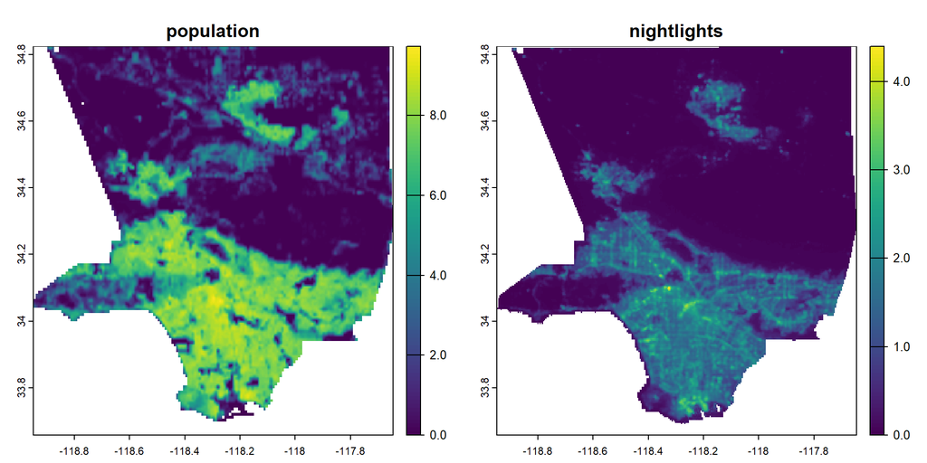

## Layers with different properties

More complex: Imputation logics. Previous examples follow the idea of interpolating existing data across the spatial domain. Imputation fills in missing values based on a prediction model. Let’s consider our two variables to make up a stylized example:

We know that population density and nightlights is correlated. We could try to predict the missing values for population based on the values of nightlights to generate the higher resolution population data. In order to do that, we train a RandomForest model on the low resolution data of population and nightlights.

```r
library(randomForest)
```

## Layers with different properties

There is some data prepping to do…

```r
# Covariates need to be in same size as outcome variable = 1km
LA_nl_2020_resampled <- resample(
  x      = LA_nl_2020,
  y      = LA_pop_2020,
  method = "bilinear"
)

# Create training data - one row per cell
train_data <- as.data.frame(LA_nl_2020_resampled,
                            xy = TRUE,
                            cells = TRUE,
                            na.rm = FALSE) |>
  left_join(as.data.frame(LA_pop_2020,
                          xy=FALSE,
                          cells=TRUE,
                          na.rm=FALSE),
            by = "cell") |>
  rename(nightlights = t2020,
         population = `US-CA_ppp_2020_1km`)

train_data <- na.omit(train_data)
```

## Layers with different properties

Ready to fit the model and predict population data on 500m grid.

```r
# Fit model
out <- randomForest(
  population ~ nightlights,
  data = train_data,
  ntree = 500
)

# Predict on the 500m grid
# Covariate names need to match
names(LA_stack)
```

```
[1] "population"  "nightlights"
```

```r
pop_500m <- predict(LA_stack, out)

names(pop_500m) <- "population_predicted"

LA_stack <- c(LA_stack, pop_500m)
```

## Layers with different properties

Of course this is a simplified approach. What other factors might correlate with population data (and nightlights) and might improve the validity of the imputed cells?

```r
terra::plot(LA_stack)
```

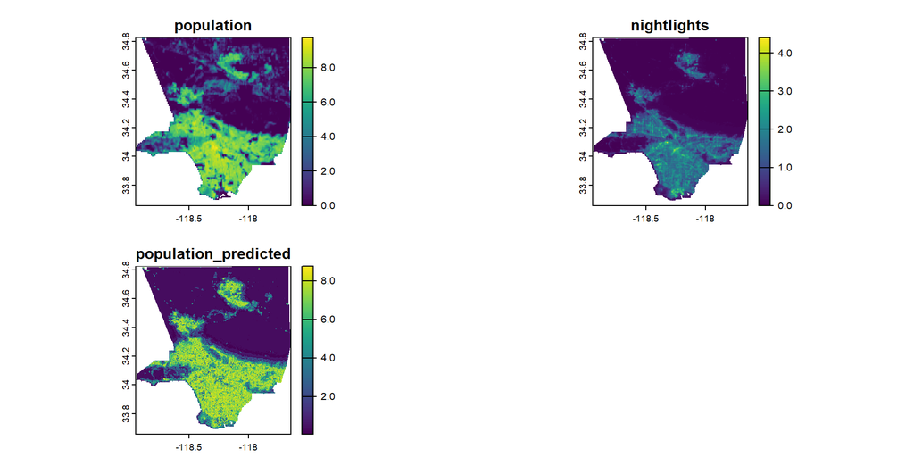

## Stack-based descriptive statistics

```r
# Global univariate means
global(LA_stack, fun = mean, na.rm=TRUE)
```

```
                          mean
population           2.9236307
nightlights          0.5277355
population_predicted 2.7936720
```

```r
# Bivariate correlations
layerCor(LA_stack, fun = "cor", use = "complete.obs")
```

```
$correlation
                     population nightlights population_predicted
population            1.0000000   0.8245851            0.8761841
nightlights           0.8245851   1.0000000            0.8736507
population_predicted  0.8761841   0.8736507            1.0000000

$mean
                     population nightlights population_predicted
population                  NaN    2.923631            2.9236307
nightlights           0.5277355         NaN            0.5277355
population_predicted  2.7936720    2.793672                  NaN

$n
                     population nightlights population_predicted
population                  NaN       59392                59392
nightlights               59256         NaN                59256
population_predicted      59256       59256                  NaN
```

## Exercise 6_2: Illuminate your region

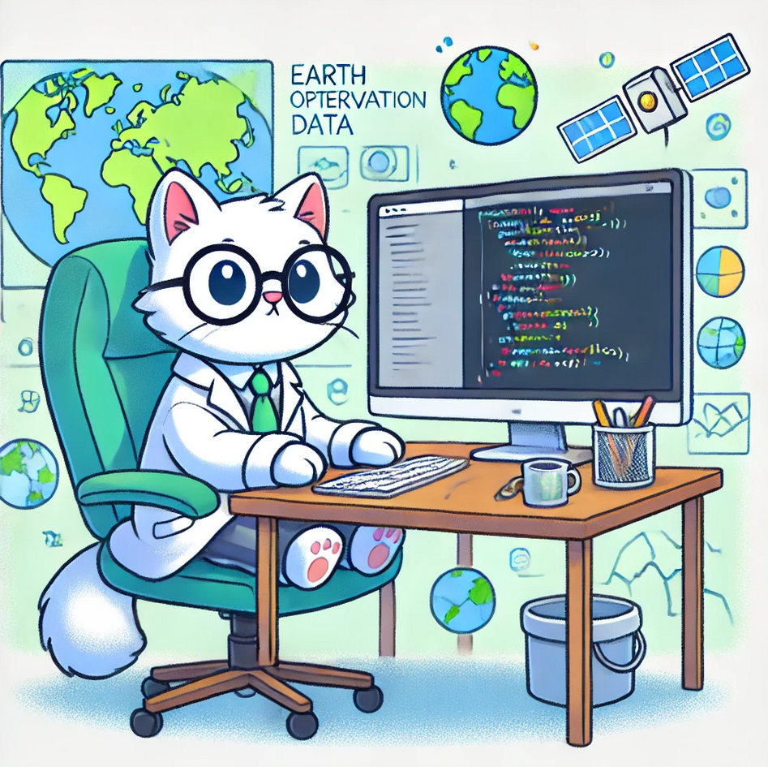

*AI-assisted picture*

[figure not shown]